# 1_redes_neuronales

2023-02-03

# Algoritmos de ML para clasificación binaria

## Redes neuronales

### Tunning de redes neuronales

Una vez seleccionada las variables utilizando StepwiseAIC para logística, se comienza con el tunning de redes neuronales para un problema de clasificación binaria con la finalidad de encontrar los parámetros que se ajusten mejor para el dataset con el que se esta trabajando, realizar un nuevo modelamiento y comparar en este caso con regresión logística y mas adelante, con los próximos algoritmos a modelar (Bagging, Random Forest etc).

### Tunning de redes neuronales con base accuracy

Utilizando las variables seleccionadas bajo StepwiseAIC se prueba un primer modelo:

```r
set.seed(12345)
control_redes <- trainControl(method = "repeatedcv", number=4, repeats=5,
    savePredictions = "all")

avnnetgrid <- expand.grid(
    size = c(5, 10, 15, 20),
    decay = c(0.01, 0.1, 0.001), bag = FALSE)

# Con las variables seleccionadas stepwiseAIC
redavnnet1 <- train(
    varObjBin ~ h10pix + temp90 + trees + trees90 + Ymin + Ymax + temp +
    humid + humid90,
    data = dengue,
    method = "avNNet",
    linout = FALSE,
    maxit = 100,
    trControl = control_redes,
    tuneGrid = avnnetgrid,
    repeats = 5,
    trace = F)

knitr::kable(redavnnet1$results, "pipe")
```

Con el código anterior se ha generado la siguiente tabla la cual puede ser de utilidad para determinar cuales parámetros podrían ser útiles al momento de elegir para entrenar el modelo:

| size | decay | bag | Accuracy | Kappa | AccuracySD | KappaSD |
| --- | --- | --- | --- | --- | --- | --- |
| 5 | 0.001 | FALSE | 0.9052328 | 0.8075327 | 0.0139857 | 0.0278779 |
| 5 | 0.010 | FALSE | 0.9229599 | 0.8423037 | 0.0131987 | 0.0269257 |
| 5 | 0.100 | FALSE | 0.9179245 | 0.8325153 | 0.0104558 | 0.0211637 |
| 10 | 0.001 | FALSE | 0.9207424 | 0.8384348 | 0.0132498 | 0.0265557 |
| 10 | 0.010 | FALSE | 0.9260815 | 0.8484666 | 0.0098502 | 0.0203012 |
| 10 | 0.100 | FALSE | 0.9197360 | 0.8361295 | 0.0099104 | 0.0201965 |
| 15 | 0.001 | FALSE | 0.9211444 | 0.8389624 | 0.0114062 | 0.0230180 |
| 15 | 0.010 | FALSE | 0.9266882 | 0.8494893 | 0.0102616 | 0.0213015 |
| 15 | 0.100 | FALSE | 0.9225561 | 0.8418606 | 0.0098902 | 0.0201859 |
| 20 | 0.001 | FALSE | 0.9244712 | 0.8454846 | 0.0101698 | 0.0207285 |
| 20 | 0.010 | FALSE | 0.9274934 | 0.8511611 | 0.0100521 | 0.0207691 |
| 20 | 0.100 | FALSE | 0.9216511 | 0.8400228 | 0.0101441 | 0.0207448 |

Se prueba el modelo otra vez pero con las variables seleccionadas con criterio BIC (son solo dos las predictoras mas la variable objetivo)

```r
# Con las variables seleccionadas BIC
redavnnet2 <- train(
    varObjBin ~ h10pix + temp90 ,
    data = data,
    method = "avNNet", linout = FALSE, maxit = 100,
    trControl = control_redes, tuneGrid = avnnetgrid,
    repeats = 5,
    trace = F)

knitr::kable(redavnnet2$results, "pipe")
```

La siguiente tabla muestra los resultados con las variables obtenidas con BIC

[output not shown]

### Tunning de redes neuronales con MAXIT

Otro criterio para realizar tunning de redes neuronales es utilizando un bucle for() que recorre un vector llamado listaiter que contiene las iteraciones a evaluar, buscando nuevamente los parámetros que podrían ser mas adecuados para este set de datos

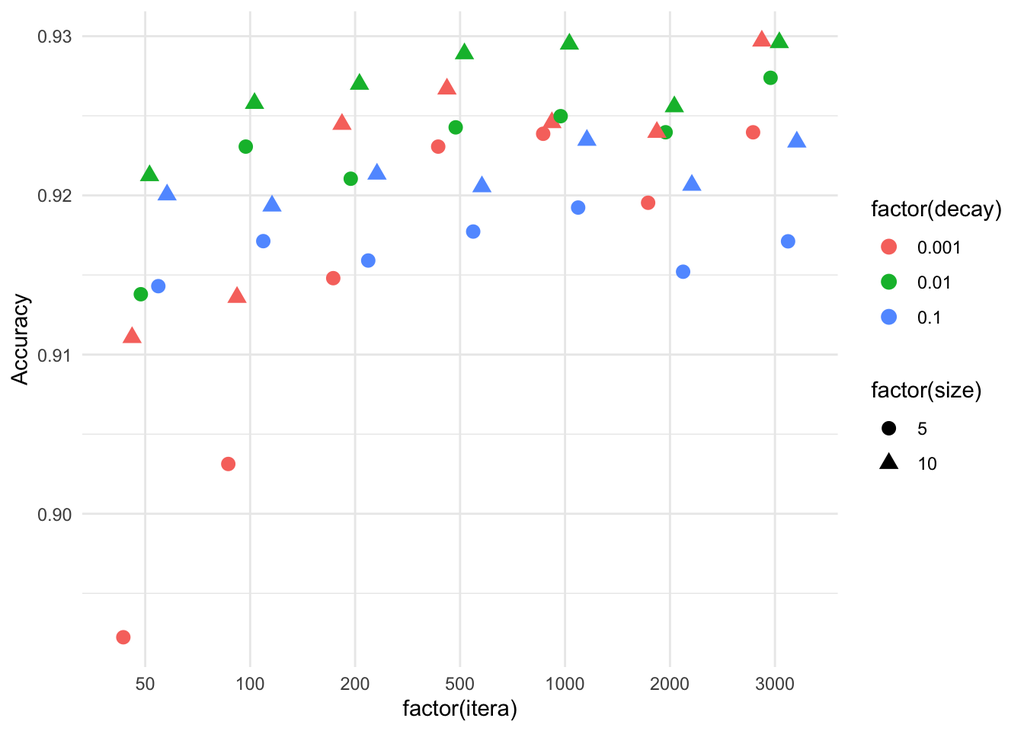

```r
listconti = c("h10pix", "temp90", "trees", "trees90", "Ymin", "Ymax",
    "temp", "humid", "humid90")

data2 <- dengue[,c(listconti, vardep)]

control_maxit <- trainControl(method = "cv", number = 4, savePredictions = "all")

set.seed(12345)
nnetgrid <-  expand.grid(size = c(5, 10), decay = c(0.01, 0.1, 0.001), bag = F)

completo <-data.frame()
listaiter<-c(50, 100, 200, 500, 1000, 2000, 3000)

for( iter in listaiter)
{
    rednnet<- train(
        varObjBin~.,
        data = data2,
        method = "avNNet",
        linout = FALSE,
        maxit = iter,
        trControl = control_redes,
        repeats = 5,
        tuneGrid = nnetgrid,
        trace = F)
    # Añado la columna del parametro de iteraciones
    rednnet$results$itera <- iter
    # Voy incorporando los resultados a completo
    completo <- rbind(completo, rednnet$results)
}

completo <- completo[order(completo$Accuracy),]

ggplot(completo, aes(x = factor(itera), y = Accuracy,
    color = factor(decay), pch = factor(size))) +
    theme_minimal() +
    geom_point(position = position_dodge(width = 0.5), size = 3)
```

### Validación cruzada repetida para redes neuronales

```r
# Validacion cruzada repetida con criterio accuracy
medias3 <-cruzadaavnnetbin(
    data = dengue,
    vardep = "varObjBin",
    listconti = c("h10pix", "temp90", "trees", "trees90", "Ymin", "Ymax",
    "temp", "humid", "humid90"),
    listclass = c(""),
    grupos = 4,
    sinicio = 1234,
    repe = 5,
    size = c(10),
    decay = c(0.010),
    repeticiones = 5,
    itera = 200)

medias3$modelo <- "Avnnet1"

medias4 <- cruzadaavnnetbin(
    data = dengue,
    vardep = "varObjBin",
    listconti = c("h10pix", "temp90"),
    listclass = c(""),
    grupos = 4,
    sinicio = 1234,
    repe = 5,
    size = c(15),
    decay = c(0.10),
    repeticiones = 5,
    itera = 200)

medias4$modelo <- "Avnnet2"

# Validacion cruzada repetida tunning maxit
medias5 <- cruzadaavnnetbin(
    data = data2,
    vardep = "varObjBin",
    listconti = c("h10pix", "temp90", "trees", "trees90", "Ymin", "Ymax",
    "temp", "humid", "humid90"),
    listclass = c(""),
    grupos = 4,
    sinicio = 1234,
    repe = 5,
    repeticiones = 5,
    itera = 1000,
    size = c(10),
    decay = c(0.01))

medias5$modelo <- "Red con maxit"
```

### Comparación de medias y boxplot

Utilizando la función genera_gráficos() se generan los gráficos de tipo boxplot para comparar los modelos creados.

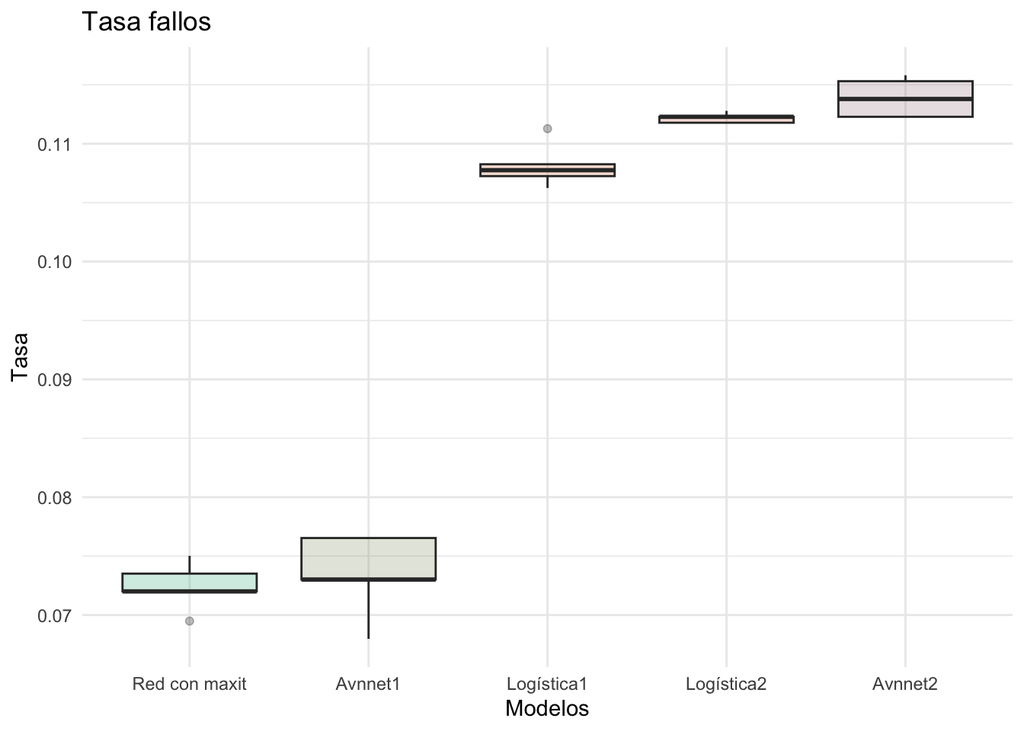

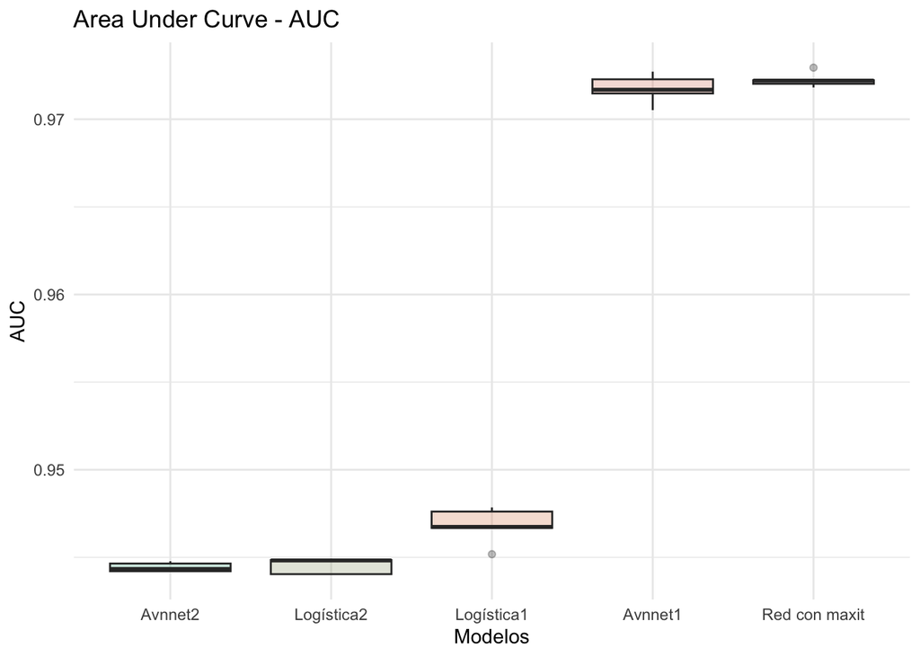

```r
genera_graficos(medias1, medias2, medias3, medias4, medias5)
```

Observaciones:

- Si se compara con los modelos generados bajo regresión logística, hay un aumento considerable del criterio AUC con redes neuronales, específicamente la que se obtuvo con las variables seleccionadas con criterio AIC mas el modelo que utilizo los parámetros que entrego el tunning con maxit.
- De todos modos esta es una comparativa inicial y aun se deben entrenar nuevos algoritmos y modelados para tomar una decisión.